# Education Data Analysis Project Proposal

July 11, 2018

## Proposal

- **Please add what questions you guys want to answer**
- How are student’s performance different between charter schools vs none charter schools (cindyst2 we can probably compare with public vs privates schools if we can)
- Does school funding, school district, teacher ratings play into any role?
- Does the background of the student such economic need index, student’s race, family composition (single family cindyst2 no dataset for this yet) play a role with the student’s performance? If so how much?
- Are there any unique programs in these schools that resulted in different student performances with similar backgrounds?

## Examine of Dataset

```r
library(readr)
#api_data = read_csv("14avgtx.txt") # cstseng: need to translate to csv

school = read_csv('2016 School Explorer.csv')
shsat = read_csv('D5 SHSAT Registrations and Testers.csv')
# Remove Adjusted Grade, New?, and Other Location Code
school = school[, c(-1, -2, -3)]
str(school, give.attr = FALSE)
```

```
## Classes 'tbl_df', 'tbl' and 'data.frame':    1272 obs. of  158 variables:
##  $ School Name                                       : chr  "P.S. 015 ROBERTO CLEMENTE" "P.S. 019 ASHER LEVY" "P.S. 020 ANNA SILVER" "P.S. 034 FRANKLIN D. ROOSEVELT" ...
##  $ SED Code                                          : num  3.1e+11 3.1e+11 3.1e+11 3.1e+11 3.1e+11 ...
##  $ Location Code                                     : chr  "01M015" "01M019" "01M020" "01M034" ...
##  $ District                                          : int  1 1 1 1 1 1 1 1 1 1 ...
##  $ Latitude                                          : num  40.7 40.7 40.7 40.7 40.7 ...
##  $ Longitude                                         : num  -74 -74 -74 -74 -74 ...
##  $ Address (Full)                                    : chr  "333 E 4TH ST NEW YORK, NY 10009" "185 1ST AVE NEW YORK, NY 10003" "166 ESSEX ST NEW YORK, NY 10002" "730 E 12TH ST NEW YORK, NY 10009" ...
##  $ City                                              : chr  "NEW YORK" "NEW YORK" "NEW YORK" "NEW YORK" ...
##  $ Zip                                               : int  10009 10003 10002 10009 10009 10009 10002 10002 10002 10002 ...
##  $ Grades                                            : chr  "PK,0K,01,02,03,04,05" "PK,0K,01,02,03,04,05" "PK,0K,01,02,03,04,05" "PK,0K,01,02,03,04,05,06,07,08" ...
##  $ Grade Low                                         : chr  "PK" "PK" "PK" "PK" ...
##  $ Grade High                                        : chr  "05" "05" "05" "08" ...
##  $ Community School?                                 : chr  "Yes" "No" "No" "No" ...
##  $ Economic Need Index                               : chr  "0.919" "0.641" "0.744" "0.86" ...
```

[output cut: 86 more lines]

```r
school = subset(school, school$`Average Math Proficiency` !=  "N/A")
school$`Average Math Proficiency` = as.numeric(school$`Average Math Proficiency`)
school$`Average ELA Proficiency` = as.numeric(school$`Average ELA Proficiency`)

school = subset(school, school$`Economic Need Index` != "N/A")
school$`Economic Need Index` = as.numeric(school$`Economic Need Index`)

school$`Percent Asian` = as.numeric(school$`Percent Asian`)
school$`Percent Black` = as.numeric(school$`Percent Black`)
school$`Percent Black / Hispanic` = as.numeric(school$`Percent Black / Hispanic`)
school$`Percent Hispanic` = as.numeric(school$`Percent Hispanic`)
school$`Percent of Students Chronically Absent` = as.numeric(school$`Percent of Students Chronically Absent`)
math_model = lm(`Average Math Proficiency` ~ `Economic Need Index` , data = school)
ela_model = lm(`Average ELA Proficiency` ~ `Economic Need Index`, data = school)

summary(math_model)
```

```
##
## Call:
## lm(formula = `Average Math Proficiency` ~ `Economic Need Index`,
##     data = school)
##
## Residuals:
##     Min      1Q  Median      3Q     Max
## -0.9738 -0.2166 -0.0324  0.1787  1.6169
##
## Coefficients:
##                       Estimate Std. Error t value Pr(>|t|)
## (Intercept)             3.7390     0.0314   119.1   <2e-16 ***
## `Economic Need Index`  -1.5947     0.0446   -35.7   <2e-16 ***
## ---
## Signif. codes:  0 '***' 0.001 '**' 0.01 '*' 0.05 '.' 0.1 ' ' 1
##
## Residual standard error: 0.329 on 1215 degrees of freedom
## Multiple R-squared:  0.512,  Adjusted R-squared:  0.512
## F-statistic: 1.28e+03 on 1 and 1215 DF,  p-value: <2e-16
```

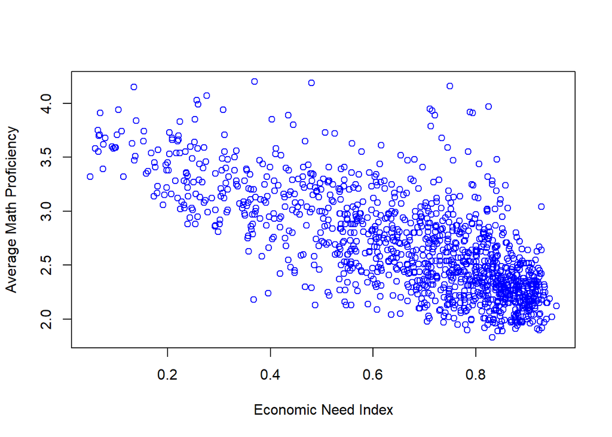

```r
plot(`Average Math Proficiency` ~ `Economic Need Index` , data = school, col = "blue")
```

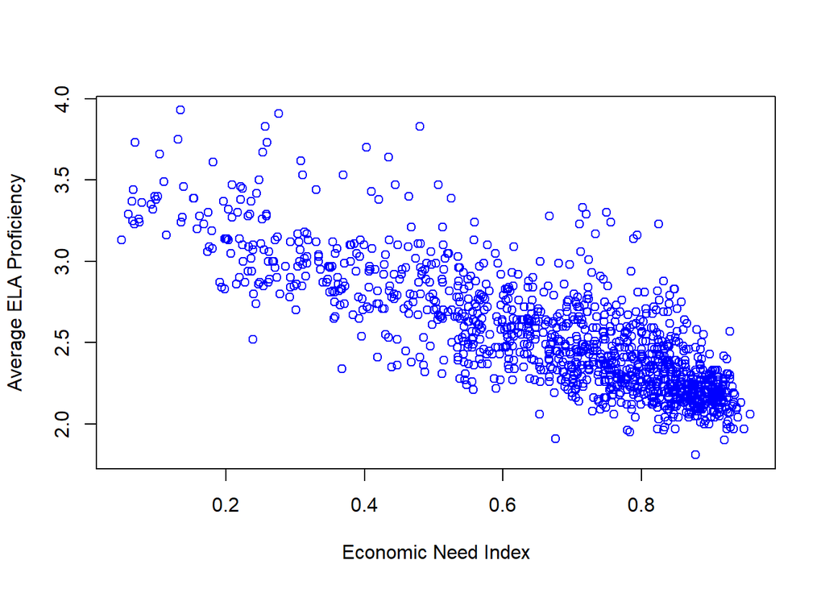

```r
plot(`Average ELA Proficiency` ~ `Economic Need Index` , data = school, col = "blue")
```

- todo: convert the 14avgtx.txt to excel, do some data clean up
- todo: clean up pyssnyc_data

## From Data-Sim guidelines

The names and NetIDs of the students who will be contributing to the group project A tentative title for the project Description of the dataset. You do not necessarily have to list all the variables, but at least mention those of greatest importance. After reading the proposal, a reader should have a good understanding of your dataset without needing to reference the data itself or other documentation. Background information on the dataset, including specific citation of its source A brief statement of the business, science, research, or personal interest you have in the dataset that you hope to explore Evidence that the data can be loaded into R. Load the data, and print the first few values of the response variable as evidence. As a group, you will submit a .zip file as you would for homework that contains an .html and .Rmd file, as well as the data if it cannot be linked online. If your data is too large to submit and cannot be linked, please let us know and we will find an alternative.